# ML models for birds vs neonics

Silvia

Thursday, November 13, 2014

I am exploring the relationship between functional groups of birds and neonics. The first part is exploratory to come up with resonable starting parameters, and then is the modeling to see how to better describe this relationship. So that you don’t get your hopes up too high, I will tell you right now that the best model to explain our data on insectivorous bird abundance vs neonis is a straight line whose slope isn’t different from zero. There, I got it out of my chest. However, it seems to me that our data or zero-inflated, so we need a special distribution for the stochastic part of our model. It ain’t easy, at least for me, to do that. But I am working on it and will hopefully have some options in the near future. I will not be offended if you guys check the models carefully to find errors that I might be doing. I am 100% new to this and, hence, not 100% sure that what I am doinng is correct. Here is the code so you can look at the exploratory graphs yourselves and at the models I have tried so far

I have mostly followed Olivia’s coding to unify criteria and make sure we are using the data in the same way.

Reading in bird traits and adding AOU codes:

```r
#Bird traits
traits_commmon_steep <- read.csv("C:/Users/slomascolo/Documents/Silvia/NCEAS-RENCI_2014/BBS_data/commonbirds_steepdecline_traits.csv")
str(traits_commmon_steep)
```

```
## 'data.frame':    33 obs. of  7 variables:
##  $ common_name  : Factor w/ 33 levels "American Wigeon",..: 1 2 3 4 5 6 7 8 9 10 ...
##  $ ohio_presence: int  1 1 1 1 0 0 1 0 1 1 ...
##  $ habitat      : Factor w/ 8 levels "forest","grassland",..: 3 3 4 1 8 1 8 3 5 2 ...
##  $ diet         : Factor w/ 5 levels "insects","mammals",..: 4 1 1 1 5 1 1 5 3 1 ...
##  $ nesting      : Factor w/ 6 levels "building","burrow",..: 4 2 3 6 5 6 1 4 6 4 ...
##  $ behavior     : Factor w/ 7 levels "aerial_dive",..: 3 2 1 4 5 4 2 3 5 2 ...
##  $ conservation : Factor w/ 3 levels "LC","NT","VU": 1 1 1 1 1 1 2 1 1 1 ...
```

```r
traits_commmon_steep_insectohio <- as.data.frame(subset(traits_commmon_steep, ohio_presence > 0))
traits_commmon_steep_insectohio$common_name <- factor(toupper(traits_commmon_steep_insectohio$common_name))
levels(traits_commmon_steep_insectohio$common_name)
```

```
##  [1] "AMERICAN WIGEON"      "BANK SWALLOW"         "BLACK TERN"
##  [4] "BLACKPOLL WARBLER"    "CHIMNEY SWIFT"        "COMMON GRACKLE"
##  [7] "COMMON NIGHTHAWK"     "EASTERN MEADOWLARK"   "FIELD SPARROW"
## [10] "GRASSHOPPER SPARROW"  "HERRING GULL"         "HORNED LARK"
## [13] "LOGGERHEAD SHRIKE"    "NORTHERN BOBWHITE"    "NORTHERN PINTAIL"
## [16] "PINE SISKIN"          "SHORT-EARED OWL"      "YELLOW-BILLED CUCKOO"
```

```r
#Adding AOU codes
AOU_codes <- read.csv("C:/Users/slomascolo/Documents/Silvia/NCEAS-RENCI_2014/BBS_data/AOU_codes.csv")
traits_commmon_steep_insectohio2 <- as.data.frame(merge(AOU_codes, traits_commmon_steep_insectohio))
```

Reading in BBS data, also following mostly Liv’s code:

```r
ohio_BBS <- read.csv("C:/Users/slomascolo/Documents/Silvia/NCEAS-RENCI_2014/BBS_data/fifty7.csv")
ohio_BBS_insect <- as.data.frame(merge(ohio_BBS, traits_commmon_steep_insectohio2))
ohio_BBS_insect$common_name<-factor(ohio_BBS_insect$common_name)
ohio_BBS_routes_countiesraw <- read.csv("C:/Users/slomascolo/Documents/Silvia/NCEAS-RENCI_2014/BBS_data/BBSdata.by.county.csv")
head(ohio_BBS_routes_countiesraw)
```

```
##   Route Year  Shannon     Lati     Longi GEOID   county
## 1     1 2000 2.926807 41.55012 -84.38984 39171 Williams
## 2     1 2004 2.808163 41.55012 -84.38984 39171 Williams
## 3     1 2010 2.926526 41.55012 -84.38984 39171 Williams
## 4     1 2009 2.890928 41.55012 -84.38984 39171 Williams
## 5     1 2007 2.616150 41.55012 -84.38984 39171 Williams
## 6     2 2010 2.423985 41.38676 -84.12166 39069    Henry
```

```r
ohio_BBS_routes_countiesraw2 <- ohio_BBS_routes_countiesraw[!duplicated(ohio_BBS_routes_countiesraw$Route), c(1,4,5,6,7)]
ohio_BBS_birds <- merge(ohio_BBS_insect, ohio_BBS_routes_countiesraw2)
ohio_BBS_birds$route_abundance <- rowSums(ohio_BBS_birds[grep("^Stop[0-9]+", names(ohio_BBS_birds))])
birdsXdiet=aggregate(ohio_BBS_birds$route_abundance, by = list(ohio_BBS_birds$GEOID, ohio_BBS_birds$year, ohio_BBS_birds$diet), sum)
names(birdsXdiet)= c("GEOID", "YEAR", "diet", "abundance")
```

I then add information on geo location.

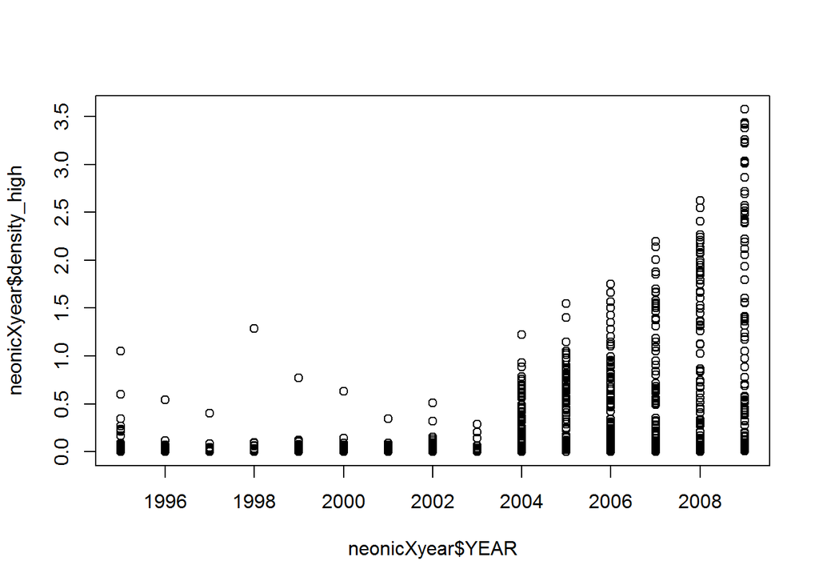

```r
geo = read.csv("C:/Users/slomascolo/Documents/Silvia/NCEAS-RENCI_2014/OH.neonicotinoids.csv", header=TRUE)
neonicXyear = aggregate (geo$density_high, by = list(geo$GEOID, geo$YEAR), sum)
names(neonicXyear)=c("GEOID", "YEAR","density_high")
plot(neonicXyear$YEAR, neonicXyear$density_high)
```

```r
birdsXgeo = merge (birdsXdiet, neonicXyear, by = c("GEOID", "YEAR"))
```

Because of the evident increase in neonics starting in 2004, I expected (or hoped) to see a similar trend in bird abundance but no, neither when I consider all functional groups together, nor when I separate by functional group:

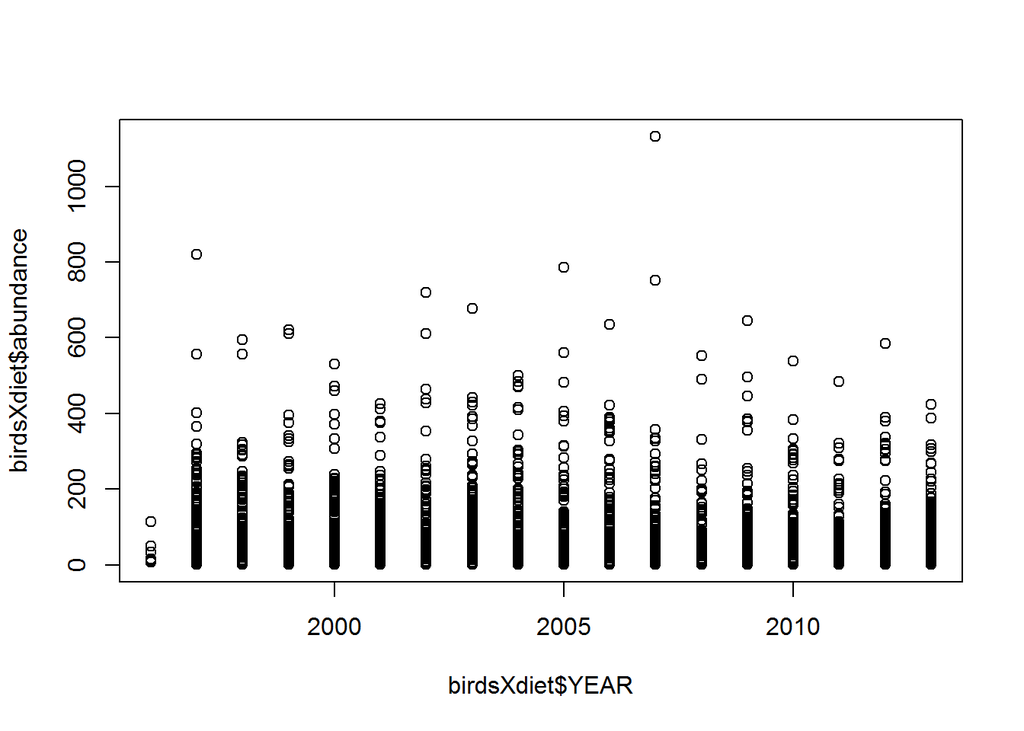

```r
plot(birdsXdiet$YEAR, birdsXdiet$abundance)
```

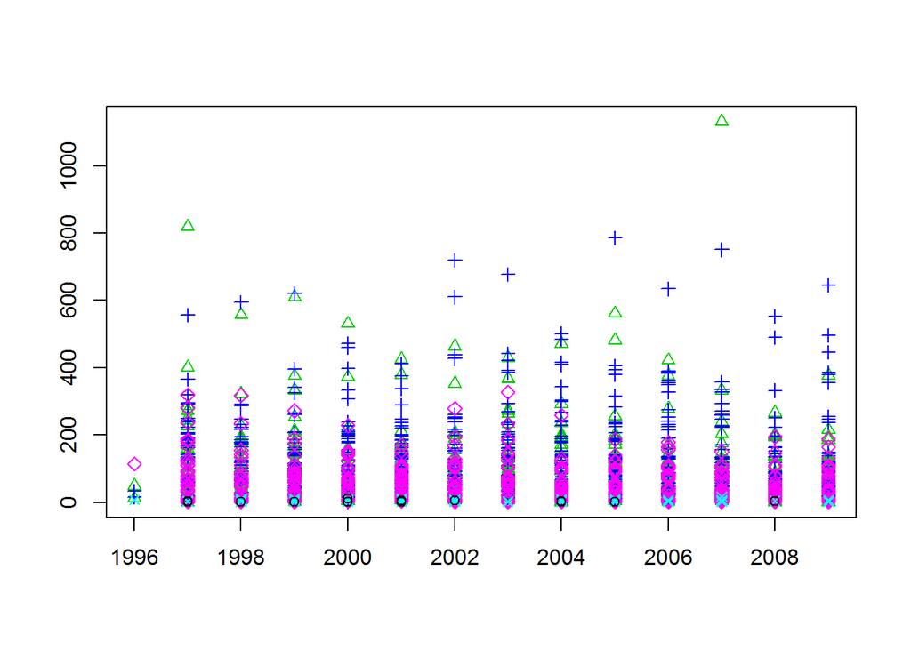

```r
ins = subset(birdsXgeo, birdsXgeo$diet =="insects")
mam = subset(birdsXgeo, birdsXgeo$diet =="mammals")
omn = subset(birdsXgeo, birdsXgeo$diet =="omnivore")
pla = subset(birdsXgeo, birdsXgeo$diet =="plants")
see = subset(birdsXgeo, birdsXgeo$diet =="seeds")
others= subset(birdsXgeo, birdsXgeo$diet!="insects")

plot(birdsXgeo$YEAR, birdsXgeo$abundance, type="n", xlab="", ylab="")
points(ins$YEAR, ins$abundance, pch=2, col=3)
points(omn$YEAR, omn$abundance, pch=3, col=4)
points(see$YEAR, see$abundance, pch=5, col=6)
points(pla$YEAR, pla$abundance, pch=4, col=5)
points(mam$YEAR, mam$abundance)
```

When I plot bird abundance against neonics concentration (density_high) there is an apparent decrease in insectivorous birds when neonics > 1.0, aproximately, but not with the other functional groups

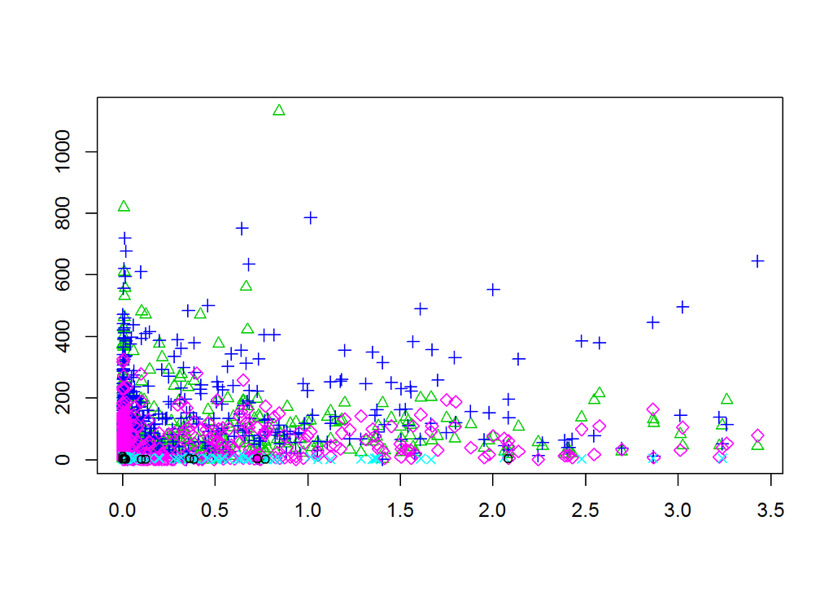

```r
plot(birdsXgeo$density_high, birdsXgeo$abundance, type="n", xlab="", ylab="")
points(ins$density_high, ins$abundance, pch=2, col=3)
points(omn$density_high, omn$abundance, pch=3, col=4)
points(see$density_high, see$abundance, pch=5, col=6)
points(pla$density_high, pla$abundance, pch=4, col=5)
points(mam$density_high, mam$abundance)
```

To estimate the initial parameters for the model I plotted an exponential curve on top of the data

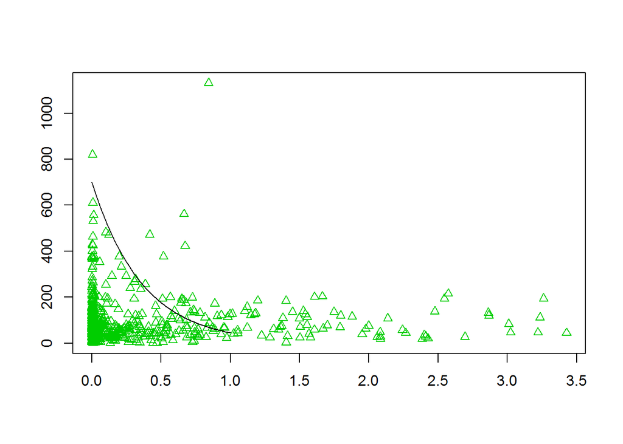

```r
#Plotting an exponential curve for a first estimate of parameters
plot(birdsXgeo$density_high, birdsXgeo$abundance, type="n", xlab="", ylab="")
points(ins$density_high, ins$abundance, pch=2, col=3)

x=ins$density_high
tete= function(x, a=700, b=2.75) {a*exp(-b*x)}
plot(tete, add=TRUE)
```

(I’m not sure why the curve only goes to 1, I have not been able to fix that…)

```r
library(bbmle)
# neg exponential with Poisson distribution
fExpNB=function(a,b){
  lambda=a*(1-exp(-b*ins$density_high))
  -sum(dpois(ins$abundance,lambda,log=T))
}

mExpPois= mle2(fExpNB, list(a=600,b=2.75))
summary(mExpPois)
```

```
## Maximum likelihood estimation
##
## Call:
## mle2(minuslogl = fExpNB, start = list(a = 600, b = 2.75))
##
## Coefficients:
##   Estimate Std. Error z value     Pr(z)
## a   98.355      0.417 235.866 < 2.2e-16 ***
## b 1855.616     34.597  53.635 < 2.2e-16 ***
## ---
## Signif. codes:  0 '***' 0.001 '**' 0.01 '*' 0.05 '.' 0.1 ' ' 1
##
## -2 log L: 50046.26
```

```r
# neg exponential with neg binom
fExpNB=function(a,b,k){
  media=a*(1-exp(-b*ins$density_high))
  -sum(dnbinom(ins$abundance,mu=media,size=k,log=T))
}

mExpNB= mle2(fExpNB, list(a=600,b=2.75,k=4))
summary(mExpNB)
```

```
## Maximum likelihood estimation
##
## Call:
## mle2(minuslogl = fExpNB, start = list(a = 600, b = 2.75, k = 4))
##
## Coefficients:
##    Estimate Std. Error z value     Pr(z)
## a 116.14404    4.95139  23.457 < 2.2e-16 ***
## b 714.81483   55.79361  12.812 < 2.2e-16 ***
## k   1.15065    0.06386  18.018 < 2.2e-16 ***
## ---
## Signif. codes:  0 '***' 0.001 '**' 0.01 '*' 0.05 '.' 0.1 ' ' 1
##
## -2 log L: 6791.048
```

```r
# linear with neg binom
fLinNB=function(a,b,k){
  media=a+b*ins$density_high
  -sum(dnbinom(ins$abundance, mu=media, size=k, log=T))
}

mLinNB=mle2(fLinNB, list(a=600,b=-10,k=1))
summary(mLinNB)
```

```
## Maximum likelihood estimation
##
## Call:
## mle2(minuslogl = fLinNB, start = list(a = 600, b = -10, k = 1))
##
## Coefficients:
##    Estimate Std. Error z value  Pr(z)
## a 95.706314   3.869826 24.7314 <2e-16 ***
## b -2.191441   5.391461 -0.4065 0.6844
## k  1.348555   0.072035 18.7207 <2e-16 ***
## ---
## Signif. codes:  0 '***' 0.001 '**' 0.01 '*' 0.05 '.' 0.1 ' ' 1
##
## -2 log L: 6674.604
```

```r
# hyperbolic with neg binom
fHypNB=function(a,b,k){
  media=a/(b+ins$density_high)
  -sum(dnbinom(ins$abundance, mu=media, size=k, log=T))
}

mHypNB=mle2(fHypNB, list(a=1100,b=0.3,k=1))
summary(mHypNB)
```

```
## Maximum likelihood estimation
##
## Call:
## mle2(minuslogl = fHypNB, start = list(a = 1100, b = 0.3, k = 1))
##
## Coefficients:
##     Estimate Std. Error z value   Pr(z)
## a 1.0954e+03 5.0152e+02  2.1841 0.02896 *
## b 1.1220e+01 5.2810e+00  2.1246 0.03362 *
## k 1.3467e+00 7.1975e-02 18.7114 < 2e-16 ***
## ---
## Signif. codes:  0 '***' 0.001 '**' 0.01 '*' 0.05 '.' 0.1 ' ' 1
##
## -2 log L: 6675.806
```

Now, are insectivores really different from the rest? I tried two models, one with all birds together and one with all others, except for insectivores, which makes the most sense to me.

```r
#All together
fLinNB_all=function(a,b,k){
  media=a+b*birdsXgeo$density_high
  -sum(dnbinom(birdsXgeo$abundance, mu=media, size=k, log=T))
}

mLinNB_all=mle2(fLinNB_all, list(a=600,b=-10,k=1))
summary(mLinNB_all)
```

```
## Maximum likelihood estimation
##
## Call:
## mle2(minuslogl = fLinNB_all, start = list(a = 600, b = -10, k = 1))
##
## Coefficients:
##    Estimate Std. Error z value  Pr(z)
## a 91.243856   2.791061 32.6915 <2e-16 ***
## b  6.715857   4.275240  1.5709 0.1162
## k  0.837110   0.025425 32.9248 <2e-16 ***
## ---
## Signif. codes:  0 '***' 0.001 '**' 0.01 '*' 0.05 '.' 0.1 ' ' 1
##
## -2 log L: 19248.49
```

```r
#Others
fLinNB_others=function(a,b,k){
  media=a+b*others$density_high
  -sum(dnbinom(others$abundance, mu=media, size=k, log=T))
}

mLinNB_others=mle2(fLinNB_others, list(a=600,b=-10,k=1))
summary(mLinNB_others)
```

```
## Maximum likelihood estimation
##
## Call:
## mle2(minuslogl = fLinNB_others, start = list(a = 600, b = -10,
##     k = 1))
##
## Coefficients:
##    Estimate Std. Error z value   Pr(z)
## a 89.524638   3.751749 23.8621 < 2e-16 ***
## b 10.857504   5.958529  1.8222 0.06843 .
## k  0.699073   0.025814 27.0810 < 2e-16 ***
## ---
## Signif. codes:  0 '***' 0.001 '**' 0.01 '*' 0.05 '.' 0.1 ' ' 1
##
## -2 log L: 12475.65
```

At the end is the table comparing all log likelihoods, which says that the linear relationship is the best fitting model, with a hyperbolic relationship coming a close second, non-differentiable from the linear model which, from the confidence intervals of the parameters (see below), says that the slope is not different from zero! Hences, I find this extremely contradictory, as it is saying that, given our dta, it is equally possible that there is no relationship at all between insectivorous bird abundance and neonics use, or that there might be a hyperbolic relationship…

```r
AICtab(mLinNB, mExpNB, mExpPois, mHypNB, mLinNB_others, mLinNB_all)
```

```
##               dAIC    df
## mLinNB            0.0 3
## mHypNB            1.2 3
## mExpNB          116.4 3
## mLinNB_others  5801.0 3
## mLinNB_all    12573.9 3
## mExpPois      43369.7 2
```

```r
confint(mLinNB)
```

```
##        2.5 %     97.5 %
## a  88.365463 103.571987
## b -11.388648  10.177118
## k   1.213143   1.495809
```

Hence, I am very happy that I was able to do this, but I am awefully confused!! One last thing that I am trying to do is to try a zero-inflated negative binomial distribution, as we do have lost of zeros in abundance. But I will owe yo uthat one as I want to upload this ASAP. I will keep working on the zero-inflated and will get back to you with the results, if I am able to figure out how to do it. I might need to go directly to the all-mighty source… Ben Bolker! I am trying myself before bugging him.